# R data science 3

Sanghoo Yoon

2019년 10월 8일

## R 데이터 분석 기초 3

지금까지 dplyr팩키지는 %>% 를 이용하여 데이터를 핸들링하는 방법을 배웠다.

다시 한번 이야기 하지만 R에서 중요한 부분은 4가지이다.

1. 데이터, 결과, 그림 등의 저장 및 활용
2. 다양한 함수()
3. 함수가 실행되지 않은 경우 package를 이용한 설치 후 library로 로드
4. 데이터의 인덱싱, 중괄호 사용[]

오늘은 merge, rbind를 이용한 데이터 합치는 방법과 데이터를 정제하는 방법을 배운다.

## 1. 파일 합치기

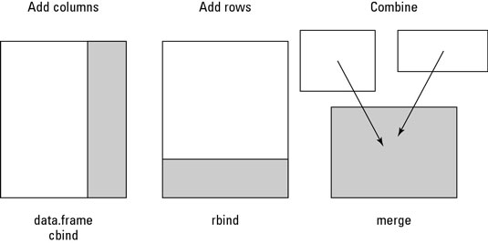

### merge()함수 : 끼워넣기

임의의 데이터 를 생성해보자.

```r
test1 <- data.frame(id = c(1, 2, 3, 4, 5), midterm = c(60, 80, 70, 90, 85))
test2 <- data.frame(id = c(4, 5, 2, 3, 6), final = c(70, 83, 65, 95, 80))
```

- 위의 자료를 합쳐보자.

R에서는 cbind() 함수가 있는데, 이는 옆에 자료를 합칠 수 있다.

```r
temp <- cbind(test1, test2)
temp
```

```
##   id midterm id final
## 1  1      60  4    70
## 2  2      80  5    83
## 3  3      70  2    65
## 4  4      90  3    95
## 5  5      85  6    80
```

하지만 이 결과가 우리가 원하는 결과는 아니다.

id를 기준으로 자료를 합치고 싶다면 **merge** 함수를 이용하자.

merge는 합치고자 하는 데이터셑 2개를 입력 후 by에 기준이 되는 변수를 설정해주면 된다.

```r
test <- merge(test1, test2, by="id")
test
```

```
##   id midterm final
## 1  2      80    65
## 2  3      70    95
## 3  4      90    70
## 4  5      85    83
```

그냥 merge를 사용하면 두개의 데이터 셋 중 겹치는 것만 생성된다.

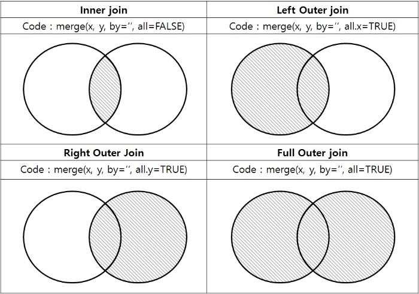

위 그림처럼 merge함수에 all, all.x, all,y 를 조정함으로써 자료를 원하는데로 생성할 수 있다.

이때 없는 자료는 NA 즉 결측치로 생성된다.

```r
(merge(test1, test2, by="id", all=TRUE))
```

```
##   id midterm final
## 1  1      60    NA
## 2  2      80    65
## 3  3      70    95
## 4  4      90    70
## 5  5      85    83
## 6  6      NA    80
```

```r
(merge(test1, test2, by="id", all.x=TRUE))
```

```
##   id midterm final
## 1  1      60    NA
## 2  2      80    65
## 3  3      70    95
## 4  4      90    70
## 5  5      85    83
```

만약 기준이 되는 변수의 명이 다르다면??

```r
test1 <- data.frame(id = c(1, 2, 3, 4, 5), midterm = c(60, 80, 70, 90, 85))
test2 <- data.frame(no = c(4, 5, 2, 3, 6), final = c(70, 83, 65, 95, 80))
```

- dplyr의 rename을 통해 동일한 이름으로 변경한다.
- by.x, by.y를 통해 끼워넣기를 직접 실행할 수 있다.
- merge(test1, test2, by.x=“id”, by.y=“no”)

### rbind() 함수 : 아래에 자료 추가하기

1반과 2반의 학생별 점수가 있다고 하자.

이제 모든 반을 합쳐서 성적을 평가하고 싶다. 이 경우 rbind()를 사용한다.

```r
test1 <- data.frame(id = c(1, 2, 3, 4, 5), midterm = c(60, 80, 70, 90, 85), class = rep(1,5))
test2 <- data.frame(id = c(1, 2, 3, 4, 5), midterm = c(70, 83, 65, 95, 80), class = rep(2,5))

test <- rbind(test1, test2)
test
```

```
##    id midterm class
## 1   1      60     1
## 2   2      80     1
## 3   3      70     1
## 4   4      90     1
## 5   5      85     1
## 6   1      70     2
## 7   2      83     2
## 8   3      65     2
## 9   4      95     2
## 10  5      80     2
```

이때 주의해야 할 사항은 rbind 하려는 자료의 변수의 이름이 동일해야 한다.

만약 아래와 같이 test1은 id, midterm, class이고 test는 id, final, class로 되어 있다면 rbind가 실행되지 않고 오류가 발생한다.

이 경우 names 함수를 이용하여 합치려는 자료의 변수 이름을 동일하게 설정하자.

- 이 경우 자료가 동일한 순서로 생성되어 있는지 다시 한번 더 확인하자.

```r
test1 <- data.frame(id = c(1, 2, 3, 4, 5), midterm = c(60, 80, 70, 90, 85), class = rep(1,5))
test2 <- data.frame(id = c(1, 2, 3, 4, 5), final = c(70, 83, 65, 95, 80), class = rep(2,5))

# test <- rbind(test1, test2)  error  발생
names(test1)
```

```
## [1] "id"      "midterm" "class"
```

```r
names(test2) <- names(test1)
test <- rbind(test1, test2)
test
```

```
##    id midterm class
## 1   1      60     1
## 2   2      80     1
## 3   3      70     1
## 4   4      90     1
## 5   5      85     1
## 6   1      70     2
## 7   2      83     2
## 8   3      65     2
## 9   4      95     2
## 10  5      80     2
```

## 도전 1

1. 공시자료를 가져와 초등학교정보와 학급수, 학생수를 합쳐보자.
2. 학생수와 학급 수에 ()소괄호가 있어 str_extract())함수로 숫자추출하였다.
3. select, group_by, filter를 이용하면 시도교육별 가장 학급수가 많은 학교, 학생수가 큰 학교를 확인 수 있다.
4. 학생수에 조건을 준다면 위기의 학교를 찾을 수 있다.
5. map()함수를 이용하면 지도위에 관심 학교의 위치를 확인 할 수 있다.

```r
library(readxl)
library(dplyr)
library(stringr)

data1 <- read.csv("F:/work/R-work/2019/KERIS/day4/2019년_공시대상학교정보(전체).csv")
data2 <- read_excel("F:/work/R-work/2019/KERIS/day4/2019년 2차_학교현황-학급수(전체).xlsx", sheet=2) #초등학교
names(data1)
```

```
##  [1] "시도교육청"         "지역교육청"         "지역"
##  [4] "정보공시.학교코드"  "학교명"             "학교급코드"
##  [7] "설립구분"           "학교특성"           "분교여부"
## [10] "설립유형"           "주야구분"           "개교기념일"
## [13] "설립일"             "법정동코드"         "주소내역"
## [16] "상세주소내역"       "우편번호"           "학교도로명우편번호"
## [19] "학교도로명주소"     "학교도로명상세주소" "위도"
## [22] "경도"               "전화번호"           "팩스번호"
## [25] "홈페이지주소"       "남녀공학구분"
```

```r
names(data2)
```

```
##  [1] "시도교육청"           "지역교육청"           "지역"
##  [4] "정보공시 \n 학교코드" "학교명"               "학교급코드"
##  [7] "설립구분"             "제외여부"             "제외사유"
## [10] "1학년"                "2학년"                "3학년"
## [13] "4학년"                "5학년"                "6학년"
## [16] "특수학급"             "순회학급"             "학급수계"
## [19] "학생수계"             "학급당학생수"
```

```r
data2$학급수 <- as.numeric(str_extract(data2$학급수계, "\\d++"))
data2$학생수 <- as.numeric(str_extract(data2$학생수계, "\\d++"))

p.data1 <- merge(data1, data2, by.x="정보공시.학교코드", by.y="정보공시 \n 학교코드")

names(p.data1)
```

```
##  [1] "정보공시.학교코드"  "시도교육청.x"       "지역교육청.x"
##  [4] "지역.x"             "학교명.x"           "학교급코드.x"
##  [7] "설립구분.x"         "학교특성"           "분교여부"
## [10] "설립유형"           "주야구분"           "개교기념일"
## [13] "설립일"             "법정동코드"         "주소내역"
## [16] "상세주소내역"       "우편번호"           "학교도로명우편번호"
## [19] "학교도로명주소"     "학교도로명상세주소" "위도"
## [22] "경도"               "전화번호"           "팩스번호"
## [25] "홈페이지주소"       "남녀공학구분"       "시도교육청.y"
## [28] "지역교육청.y"       "지역.y"             "학교명.y"
## [31] "학교급코드.y"       "설립구분.y"         "제외여부"
## [34] "제외사유"           "1학년"              "2학년"
## [37] "3학년"              "4학년"              "5학년"
## [40] "6학년"              "특수학급"           "순회학급"
## [43] "학급수계"           "학생수계"           "학급당학생수"
## [46] "학급수"             "학생수"
```

```r
table(p.data1$시도교육청.x)
```

```
##
##         강원도교육청         경기도교육청       경상남도교육청
##                  378                 1300                  519
##       경상북도교육청     광주광역시교육청     대구광역시교육청
##                  508                  156                  229
##     대전광역시교육청     부산광역시교육청     서울특별시교육청
##                  150                  304                  600
## 세종특별자치시교육청     울산광역시교육청     인천광역시교육청
##                   48                  122                  260
##       전라남도교육청       전라북도교육청 제주특별자치도교육청
##                  465                  423                  118
##       충청남도교육청       충청북도교육청
##                  420                  268
```

```r
# 시도교육청 별로 학급수가 가장 많은 초등학교는
p.data1 %>% select(시도교육청.x, 학교명.x, 학급수, 위도, 경도) %>% group_by(시도교육청.x) %>% filter(학급수==max(학급수))
```

```
## # A tibble: 18 x 5
## # Groups:   시도교육청.x [16]
##    시도교육청.x         학교명.x         학급수  위도  경도
##    <fct>                <fct>             <dbl> <dbl> <dbl>
##  1 서울특별시교육청     서울신정초등학교     75  37.5  127.
##  2 부산광역시교육청     명호초등학교         54  35.1  129.
##  3 대구광역시교육청     대구유가초등학교     60  35.7  128.
##  4 광주광역시교육청     신창초등학교         56  35.2  127.
##  5 광주광역시교육청     성덕초등학교         56  35.2  127.
##  6 대전광역시교육청     대전반석초등학교     51  36.4  127.
##  7 울산광역시교육청     무거초등학교         49  35.6  129.
##  8 세종특별자치시교육청 도담초등학교         63  36.5  127.
##  9 경기도교육청         탄벌초등학교         64  37.4  127.
## 10 경기도교육청         청수초등학교         64  37.7  127.
## 11 강원도교육청         황지초등학교         48  37.2  129.
## 12 충청북도교육청       솔밭초등학교         60  36.6  127.
## 13 충청남도교육청       환서초등학교         70  36.8  127.
## 14 전라북도교육청       전주화정초등학교     62  35.8  127.
## 15 전라남도교육청       오룡초등학교         57  34.8  126.
## 16 경상북도교육청       포항원동초등학교     60  36.0  129.
## 17 경상남도교육청       수남초등학교         65  35.2  129.
## 18 제주특별자치도교육청 한라초등학교         63  33.5  126.
```

```r
p.data1 %>% select(시도교육청.x, 학교명.x, 학생수, 위도, 경도) %>% group_by(시도교육청.x) %>% filter(학생수==max(학생수))
```

```
## # A tibble: 16 x 5
## # Groups:   시도교육청.x [16]
##    시도교육청.x         학교명.x         학생수  위도  경도
##    <fct>                <fct>             <dbl> <dbl> <dbl>
##  1 서울특별시교육청     서울대도초등학교   2157  37.5  127.
##  2 부산광역시교육청     명호초등학교       1690  35.1  129.
##  3 대구광역시교육청     대구경동초등학교   1859  35.9  129.
##  4 광주광역시교육청     수완초등학교       1795  35.2  127.
##  5 대전광역시교육청     한밭초등학교       1657  36.4  127.
##  6 울산광역시교육청     온남초등학교       1269  35.4  129.
##  7 세종특별자치시교육청 도담초등학교       1528  36.5  127.
##  8 경기도교육청         탄벌초등학교       2178  37.4  127.
##  9 강원도교육청         반곡초등학교       1177  37.3  128.
## 10 충청북도교육청       솔밭초등학교       1793  36.6  127.
## 11 충청남도교육청       환서초등학교       2172  36.8  127.
## 12 전라북도교육청       전주화정초등학교   1627  35.8  127.
## 13 전라남도교육청       오룡초등학교       1600  34.8  126.
## 14 경상북도교육청       옥계동부초등학교   1848  36.1  128.
## 15 경상남도교육청       수남초등학교       1869  35.2  129.
## 16 제주특별자치도교육청 한라초등학교       1831  33.5  126.
```

```r
p.data1 %>% select(시도교육청.x, 학교명.x, 학생수, 위도, 경도) %>% group_by(시도교육청.x) %>% filter(학생수==min(학생수))
```

```
## # A tibble: 23 x 5
## # Groups:   시도교육청.x [16]
##    시도교육청.x         학교명.x               학생수  위도  경도
##    <fct>                <fct>                   <dbl> <dbl> <dbl>
##  1 서울특별시교육청     서울본동초등학교          102  37.5  127.
##  2 부산광역시교육청     공덕초등학교               34  35.3  129.
##  3 대구광역시교육청     대구조야초등학교           52  35.9  129.
##  4 광주광역시교육청     임곡초등학교               35  35.2  127.
##  5 대전광역시교육청     기성초등학교길헌분교장     17  36.2  127.
##  6 울산광역시교육청     연암초등학교효문분교장      2  35.6  129.
##  7 세종특별자치시교육청 의랑초등학교               63  36.6  127.
##  8 세종특별자치시교육청 연동초등학교               63  36.6  127.
##  9 경기도교육청         대남초등학교풍도분교장      1  37.1  126.
## 10 강원도교육청         노천초등학교                0  37.6  128
## # ... with 13 more rows
```

```r
p.data1 %>% select(시도교육청.x, 학교명.x, 학생수, 위도, 경도) %>% group_by(시도교육청.x) %>% filter(학생수<10) %>%  summarise(count=n())
```

```
## # A tibble: 11 x 2
##    시도교육청.x         count
##    <fct>                <int>
##  1 강원도교육청            27
##  2 경기도교육청             6
##  3 경상남도교육청          10
##  4 경상북도교육청          24
##  5 울산광역시교육청         2
##  6 인천광역시교육청         6
##  7 전라남도교육청          35
##  8 전라북도교육청          12
##  9 제주특별자치도교육청     2
## 10 충청남도교육청           9
## 11 충청북도교육청           2
```

```r
out1 <- p.data1 %>% select(시도교육청.x, 학교명.x, 학생수, 위도, 경도) %>% group_by(시도교육청.x) %>% filter(학생수<5)

out1$위도[out1$위도>100]
```

```
## [1] 343505.8
```

```r
out1$위도[out1$위도>100]=out1$위도[out1$위도>100]/10000
out1$위도
```

```
##  [1] 37.77378 35.56708 35.45772 37.54221 37.11123 36.95582 38.54179
##  [8] 38.07458 37.92565 37.98753 37.23594 37.15985 38.15362 37.27009
## [15] 37.30916 37.60000 37.00000 37.04840 36.91017 36.22878 36.68286
## [22] 36.04280 35.73537 35.84195 34.64150 34.48554 34.43298 34.35058
## [29] 35.20213 34.30937 34.28530 34.56878 34.67890 34.73819 34.68839
## [36] 34.77474 34.77285 34.82267 35.24740 34.72250 34.76664 34.65164
## [43] 34.27132 34.20094 34.18835 34.57418 36.92786 36.89416 36.03273
## [50] 37.04066 36.92425 35.93465 36.25102 34.88976 34.78402 34.74772
```

```r
out1$경도[out1$경도>1000]=out1$경도[out1$경도>1000]*0.01
out1$경도
```

```
##  [1]   124.75086   129.36836   129.17779   126.79108   126.39293
##  [6]   126.87772   128.40143   128.47936   128.77689   128.52975
## [11]   128.51197   128.30884   128.12336   128.60703   128.43481
## [16]   128.00000   128.40000   126.43325   126.33411   126.08175
## [21]   126.13924   126.54874   126.45663   126.49216   126.73367
## [26]   127.80540   127.80081 12744.07400   126.13655   125.97595
## [31]   127.35880   127.73497   125.37783   125.44488   126.17006
## [36]   126.31416   127.58994   127.55538   127.59089   127.31435
## [41]   127.49197   125.46825   125.99387   126.75385   126.50108
## [46]   127.72288    29.05495   129.00605   128.83292   129.32220
## [51]   129.13805   129.52339   129.21499   128.07471   128.36711
## [56]   128.40693
```

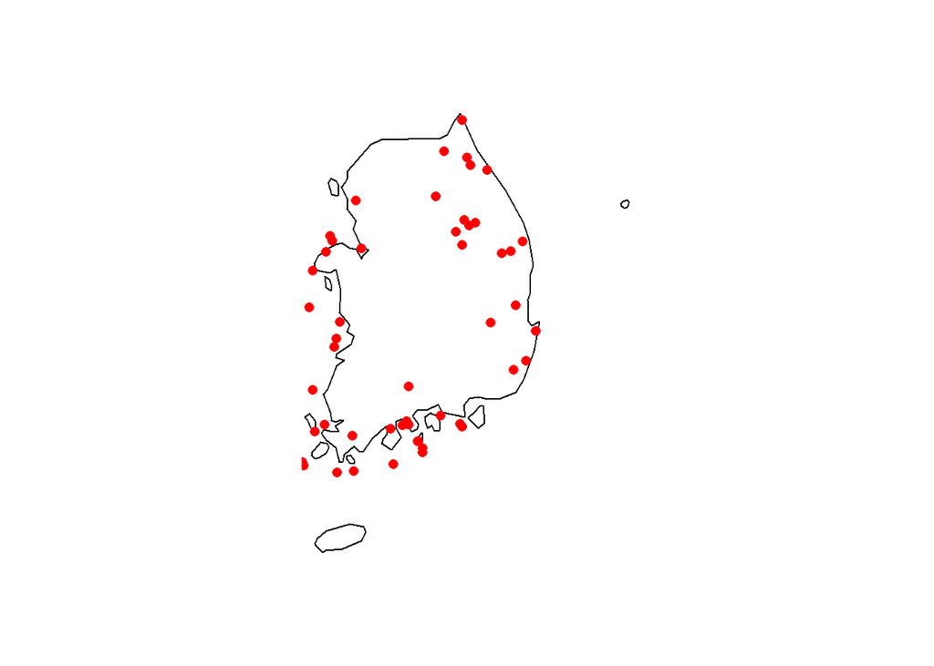

```r
library(maps)
map('world','South Korea')
points(out1$경도, out1$위도, pch=16, col="red")
```

### 문제 : 중학교 학생 수가 50 미만인 학교는 어느 지역교육청에 많은 가요?

```
## # A tibble: 1 x 2
##   지역교육청.x           count
##   <fct>                  <int>
## 1 전라남도고흥교육지원청    11
```